# Los Angeles Redlining

Exploring patterns of environmental justice

Author

Steven Mitchell

Published

April 29, 2025

[figure not shown]

```r
# load packages
library(sf)
library(tidyverse)
library(tmap)
library(here)
library(viridisLite)
```

## Part 1: Legacy of redlining in current environmental (in)justice

```r
# Load & Filter EJScreen Data
ej_la <- read_sf(here("data", "ejscreen", "EJSCREEN_2023_BG_StatePct_with_AS_CNMI_GU_VI.gdb")) %>%
  dplyr::filter(ST_ABBREV == "CA") %>% # filter to CA
  dplyr::filter(CNTY_NAME == "Los Angeles County") %>% # filter to LA County
  st_make_valid() # make valid for mapping

# Load & wrangle Redlining Data
rl_data <- st_read(here("data", "mapping-inequality", "mapping-inequality-los-angeles.json")) %>%
  st_make_valid() # make valid for mapping

# reproject redlining data to match EJScreen CRS
rl_transformed <- st_transform(rl_data, crs = st_crs(ej_la))

# dissolve to LA County and calculate average values
la_county <- aggregate(ej_la, by = list(ej_la$CNTY_NAME), FUN = mean)

# CRS consistency check
if(st_crs(ej_la) == st_crs(rl_transformed)) {
  print("coordinate reference systems match")
} else{
  error("coordinate reference systems do not match")
}
```

### Map of Historical Redlining in Los Angeles County

Home Owners’ Loan Corporation (HOLC) rating ranking system, (A (green), B (blue), C (yellow), D (red)) was used to block access to loans for home ownership. This practice was known as “Redlining”

```r
tmap_mode("view")

map_la <- tm_basemap("Esri")+
#  tm_shape(ej_la)+
#  tm_polygons(col = "LOWINCOME",
#              palette = mako(3000, direction = -1),
#              title = "Percent Low Income")+
  tm_shape(rl_data)+
  tm_polygons(col = "grade",
              palette = c("green", "blue", "yellow", "darkred"),
              alpha = 0.5,
              title = "HOLC Code")+
  tm_shape(la_county)+
  tm_borders(lwd = 4) +
  tm_layout(main.title = "Historical Redlining in Los Angeles County",
            legend.frame = TRUE)+
  tm_scale_bar(position = c("left", "bottom"))

tmap_save(map_la, "map_la.html")
```

[figure not shown]

Redlining in Los Angeles County

### Map Interpretation

Redlined neighborhoods constitute 15.3% of the total population in and 15% of census blocks in Los Angeles County. Many Redlined neighborhoods are in high density urban centers such as East LA and/or adjacent to industrial zones such as the port of Long Beach.

| HOLC Rating | Census Blocks | % of Census Blocks |
| --- | --- | --- |
| A | 449 | 5% |
| B | 1239 | 13.8% |
| C | 3058 | 34% |
| D | 1346 | 15% |
| NA | 2896 | 32.2% |

```r
# join the redlining categories onto the EJ Screen data
ej_rl_leftjoin <- st_join(ej_la, rl_transformed)

# make a table of census blocks vs RL neighborhoods
table_blocks <- ej_rl_leftjoin %>%
  group_by(grade) %>%
  summarise(n_blocks = n()) %>% # count census blocks within each redlining category
  st_drop_geometry() %>% # remove the geometries so the math works
  mutate(percent_blocks = n_blocks/sum(n_blocks) * 100) # calculate percentages by RL category

# make a table of population totals
table_pop <- ej_rl_leftjoin %>%
  group_by(grade) %>%
  summarise(pop = sum(ACSTOTPOP)) %>% # calculate sum population by HOLC rating
  st_drop_geometry()%>% # remove the geometries so the math works
  mutate(percent_pop = pop/sum(pop) * 100) # calculate percentages by RL category

# make a table of percentile low income
table_lowinc <- ej_rl_leftjoin %>%
  group_by(grade) %>%
  summarise(income = mean(LOWINCPCT)) %>% # calculate average percentage of low income
  st_drop_geometry()

# make a table of percentile PM2.5
table_pm25 <- ej_rl_leftjoin %>%
  group_by(grade) %>%
  summarise(pm = mean(P_PM25)) %>% # calculate average 2.5 particulate matter
  st_drop_geometry()

# make a table of percentile low life expectancy
table_life_exp <- ej_rl_leftjoin %>%
  drop_na(P_LIFEEXPPCT) %>%
  group_by(grade) %>%
  summarise(life_exp = mean(P_LIFEEXPPCT)) %>% # calculate average low life expectancy
  st_drop_geometry()
```

```r
# make figures

chart_low_inc <- ggplot(table_lowinc)+
  geom_col(aes(x=grade, y = income))+
  labs(x="HOLC Rating", y="Percent Low Income")+
  theme_bw()

ggsave("chart_low_inc.png", chart_low_inc)

chart_pm25 <- ggplot(table_pm25)+
  geom_col(aes(x=grade, y = pm))+
  labs(x="HOLC Rating", y="Percentile for Particulate Matter 2.5 Exposure")+
  theme_bw()

ggsave("chart_pm25.png", chart_pm25)

chart_life_exp <- ggplot(table_life_exp)+
  geom_col(aes(x = grade, y = life_exp))+
  labs(x = "HOLC Rating", y = "Percentile for Low Life Expectancy")+
  theme_bw()

ggsave("chart_life_exp.png", chart_life_exp)
```

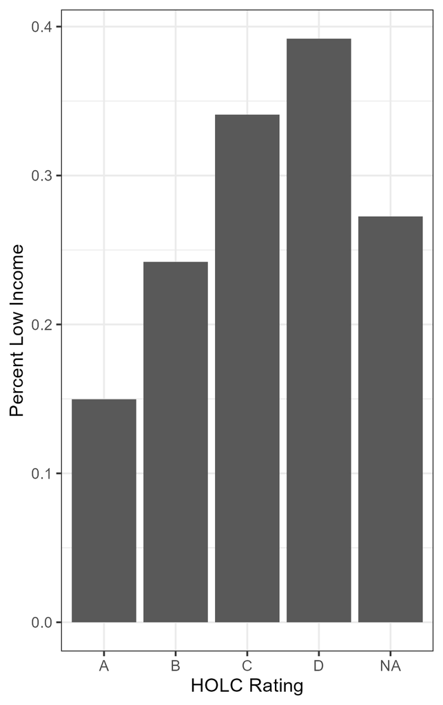

Percent Low Income by HOLC rating.

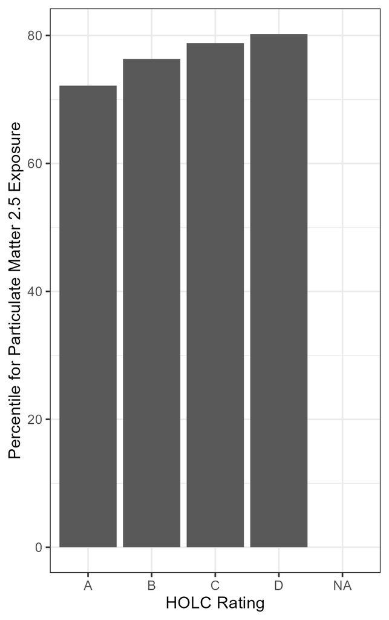

Percentile of Particulate Matter 2.5 by HOLC rating.

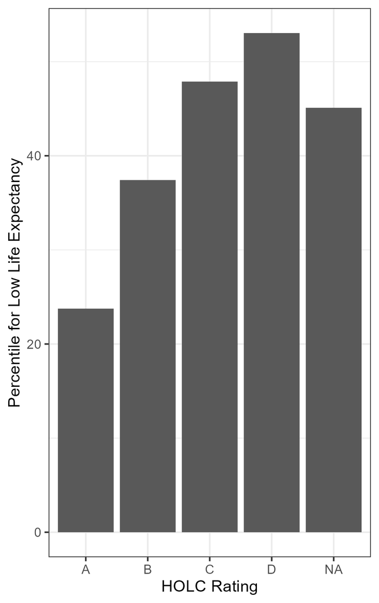

Percentile of low life expectancy by HOLC rating.

### Results Interpretation

Redlined neighborhoods (HOLC D) are the highest in percent low income, percentile of particulate matter exposure, and percentile for low life expectancy. Together, these points indicate that the most vulnerable people (low income) experience the most air quality risk (PM 2.5 exposure) and the lowest life expectancy compared to other parts of Los Angeles County. The impacts of Redlining are lethal.

## Part 2: Legacy of redlining in biodiversity observations

```r
#load, wrangle, and inspect data
birds <- read_sf(here("data", "gbif-birds-LA")) %>%
  filter(year == 2022)

# reproject CRS
birds_transformed <- st_transform(birds, crs = st_crs(ej_la))

# CRS consistency check
if(st_crs(rl_transformed) == st_crs(birds_transformed)) {
  print("coordinate reference systems match")
} else{
  error("coordinate reference systems do not match")
}

# join the data
birds_rl_leftjoin <- st_join(rl_transformed, birds_transformed)

# summarize in a table
table_birds <- birds_rl_leftjoin %>%
  group_by(grade) %>%
  summarise(bird_obs = n()) %>% # count census blocks within each redlining category
  st_drop_geometry() %>% # remove the geometries so the math works
  mutate(percent_obs= bird_obs/sum(bird_obs) * 100) # calculate percentages by RL category

# chart the data
chart_birds <- ggplot(table_birds)+
  geom_col(aes(x=grade, y = percent_obs))+
  labs(x = "HOLC rating", y = "Percentage of Bird Observations")+
  theme_bw()

ggsave("chart_birds.png", chart_birds)
```

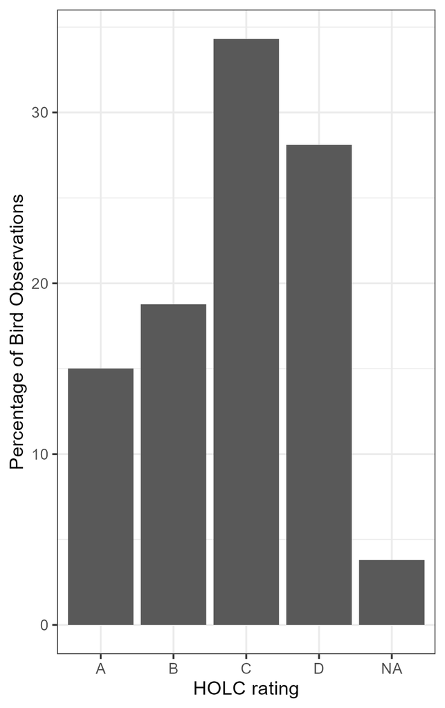

Bird observations across HOLC ratings.

### Results Interpretation

These results do not match the findings from Ellis-Soto et al. 2023. Whereas that study found that historically redlined neighborhoods were drastically under-surveyed in citizen science, these results show the second highest number of bird observations in those same redlined neighborhoods. This is surprising because of the human health impacts illustrated in Part 1. There could be a number of possible explanations for the discrepancy, one of which could be disparate vulnerabilities to air pollution between humans and birds.

### Citations

[output not shown]